## **Question - Can we forecast which defensive personnel to use in certain circumstances?**

The first question that came to mind was what would a coach want to know given the data that was provided? The best question that I could come up with what defensive personnel should I play, given certain circumstances that a coach would see before a play. In other words, a defensive coach can see what the down is, how many yards until a first down, the formation of the offense, the time left on the clock, and of course the score.

Therefore, given these five variables that a coach can see before a play begins, what defensive personnel should he implement? Personally, I thought that this questions would be a fun one to answer using Machine Learning and some of the techniques that we learned in DAIII.

The first step was obviously to clean the data as well as filter it down to the five predictor variables plus the response variable. In this case, we are using EPA (Expected Points Added) as the response variable and the variables we are running the regression to predict.

## Exploratory Set-Up

The one aspect of this analysis that was worry-some was an expected correlation between the EPA and where the team is physically on the field (what yardage line). This worry was relaxed as we look at the graph below showing the EPA vs. Yardage Line Correlation Scatter-plot.

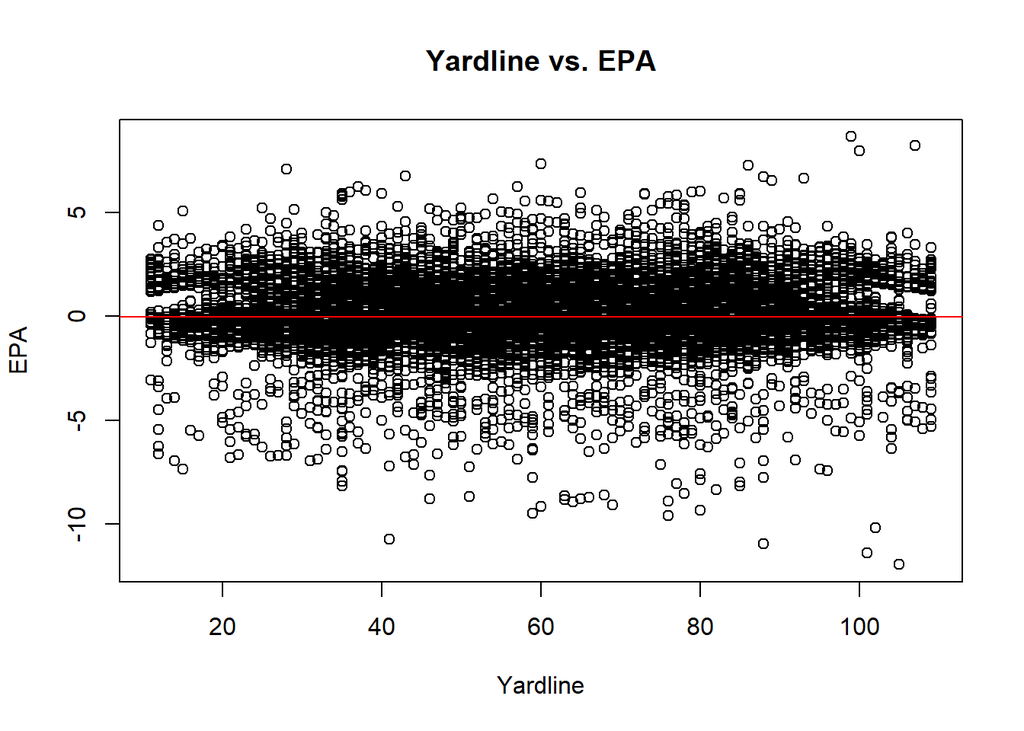

With a a correlation of 0.0074285, or basically zero, there is no correlation between these two variables. Doing a little deeper digging, you will find that the Result of the play (or the yardage gained during the play) is the only variable that has a major correlation with EPA.

In order to do this analysis, I subsetted defensive personnel down into the top 10 defensive formations. This included any personnel that had 100 or more snaps throughout the 2019 season.

One more worry that I came across was the idea that teams might implement these formations on specific parts of the field (in certain situations) more often than others. So, I looked into the average and standard deviation of field positions for each of the ten defensive personnel units. The table below shows these numbers.

Field Position Statistics

| DefenseForm | AvgFieldPos | SdFieldPos |
| --- | --- | --- |
| 1 | 59.67032 | 21.61905 |
| 2 | 60.36730 | 23.95383 |
| 3 | 57.67470 | 23.23101 |
| 4 | 60.43704 | 23.86904 |
| 5 | 58.34703 | 23.64528 |
| 6 | 60.31528 | 22.14302 |
| 7 | 59.64977 | 23.34486 |
| 8 | 60.87179 | 22.98114 |
| 9 | 59.52081 | 24.02819 |
| 10 | 59.55282 | 24.45701 |

Looking at the data, I would once again say that we are good to go with the analysis as there are no distinct differences between each of the defensive personnels.

### **Method**

The next step that I did was to subset the data down into each of the personnels. Meaning that all of the plays that were run by each of the 10 formations had its own subsets. I did this so that I could run a different model for each personnel.

I first started using gradient boosting. Gradient tended to work very well in a lot of the analysis that I have done before, and so this is what I wanted to start with. I tuned the parameters of iteration.depth and n.trees for each subset to obtain the optimal model for each formation. Unfortunately, using this kind of model produced results that were worse than guessing zero for the EPA each time.

Therefore, the next step was to change directions and change models. I decided to go with Ridge and Lasso Regression. These models seemed a little simpler, and might help when we don’t have as many variables. I tuned each model using the cv.glmnet function and got the best model for each subset once again.

### **Modeling**

So, now we have ten different models for each Ridge Regression and Lasso Regression, each built from the subset of data from each of the top ten defensive personnel units. From here, I will make predictions on the test set with each model. In essence, what I am doing here is saying, “If we run this defensive personnel in this situation, what is our expected EPA?”

With the ten predictions for each type of model, I then develop the MSE. This is done by using the actual defensive personnel used in each play type, and using that prediction. Again, to explain better, say that the first play was run using a defensive personnel of 3 DL, 2 LB, 6 DB, then we would take the EPA prediction from the model that was derived from all of the plays from the subset of 3 DL, 2 LB, 6 DB plays.

### **Results**

Now, using the Ridge model, the last thing that I wanted to do was to find the optimal defensive formation for each given play in the test set. This was done by finding the minimum EPA prediction out of all ten predictions and backtracking to what defensive personnel was used to make that prediction. This will in turn give us the optimal defensive personnel based on the minimum EPA

With this in mind, there are many implementations for NFL coaches. Now, as we can see below, we have a range of yardages that each defensive personnel should be implemented.

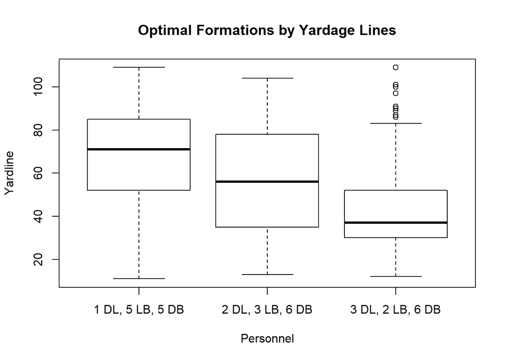

Lastly, another implementation would be to see which defensive personnel unit on average is the best on each down, from first down to fourth downs. On fourth downs, we took out any punts, so we are only looking at plays where the other team was going for it. The table below shows which formations did the best on each of the four downs.

Down Data

| Down | OptForm |
| --- | --- |
| 1 | 1 DL, 5 LB, 5 DB |
| 2 | 1 DL, 5 LB, 5 DB |
| 3 | 1 DL, 4 LB, 6 DB |
| 4 | 1 DL, 4 LB, 6 DB |

This table allows us to see which defensive personnels to use during each down, which is a useful tool if you are a coach.

## Conclusion

There are some obvious faults with this data analysis that, given a little more time, I would have loved to jump into. First, its obvious at the end of the analysis that I really should not have included defensive personnels that only include 1 DL. These plays tend to simply happen at the end of the games where much of the focus is put on defending the pass.

I do think this analysis was really cool though, at least in the implementation. Being able to have a model that willgive you your optimal formation on defensive given the circumstances pre-snap is a really cool and interesting application. But, there are instances in a football game where you cannot make substitutions, or the other team audibles causing everything to crash.

In the end I am happy with the work that I was able to complete and looking forward to next semester!

[output not shown]